# Estudios de Informática, Multimedia y Telecomunicaciones

#### 3.2.5.4 Análisis Multivariante:

En esta sección, procedemos a hacer el análisis mutivariante. Para ello, lo más usual es utilizar una matriz de correlación de las distintas variables numéricas y el coeficiente Pearce de significancia estadística:

```r
# Cargamos las librerías
library(funModeling)
library(scales)
library(dplyr)
library(readxl)
library(GGally)
library(corrplot)
library(PerformanceAnalytics)
library(ggcorrplot)
library(psych)
library("factoextra")
library("Sleuth2")

# Variables cuantitativas
quanvars <- c("brewery_id", "review_overall", "review_time", "review_aroma", "review_appearance", "review_palate", "review_taste")

# Elegimos solo variables cuantitativas
quandatos <- data.frame(rev[, quanvars])

# Matriz de datos
quandatos_m <- matrix(nrow=length(rev[, 1]), ncol=length(quanvars))
colnames(quandatos_m) <- quanvars

# Obtenemos el subconjunto de variables numéricas a partir del dataset
for (i in 1:length(quanvars)){
  quandatos_m[,i] <- round(as.numeric(quandatos[, i]), 7)
}

# Calculamos el coeficiente de correlación y significancia (p-value)
rcorr(quandatos_m)
```

```
##                   brewery_id review_overall review_time review_aroma
## brewery_id              1.00          -0.01        0.22         0.02
## review_overall         -0.01           1.00        0.02         0.61
## review_time             0.22           0.02        1.00         0.06
## review_aroma            0.02           0.61        0.06         1.00
## review_appearance       0.00           0.50        0.05         0.56
## review_palate           0.00           0.70        0.05         0.61
## review_taste            0.00           0.79        0.04         0.71
##                   review_appearance review_palate review_taste
## brewery_id                     0.00          0.00         0.00
## review_overall                 0.50          0.70         0.79
## review_time                    0.05          0.05         0.04
## review_aroma                   0.56          0.61         0.71
## review_appearance              1.00          0.56         0.54
## review_palate                  0.56          1.00         0.73
## review_taste                   0.54          0.73         1.00
##
## n= 1496589
##
##
## P
##                   brewery_id review_overall review_time review_aroma
## brewery_id                   0.0000         0.0000      0.0000
## review_overall    0.0000                    0.0000      0.0000
## review_time       0.0000     0.0000                     0.0000
## review_aroma      0.0000     0.0000         0.0000
## review_appearance 0.0000     0.0000         0.0000      0.0000
## review_palate     0.0387     0.0000         0.0000      0.0000
## review_taste      0.8099     0.0000         0.0000      0.0000
##                   review_appearance review_palate review_taste
## brewery_id        0.0000            0.0387        0.8099
## review_overall    0.0000            0.0000        0.0000
## review_time       0.0000            0.0000        0.0000
## review_aroma      0.0000            0.0000        0.0000
## review_appearance                   0.0000        0.0000
## review_palate     0.0000                          0.0000
## review_taste      0.0000            0.0000
```

Como es de esperar, existe una alta correlación positiva entre las variables aroma, apariencia, paladar y sabor respecto a la calificación total.

Por tanto, existe una correlación positiva moderada entre ellas. En otras palabras, existe una relación de dependencia positiva entre dichas variables.

Graficamos la matriz de correlación para visualizar lo antes mencionado utilizando dos librerías distintas:

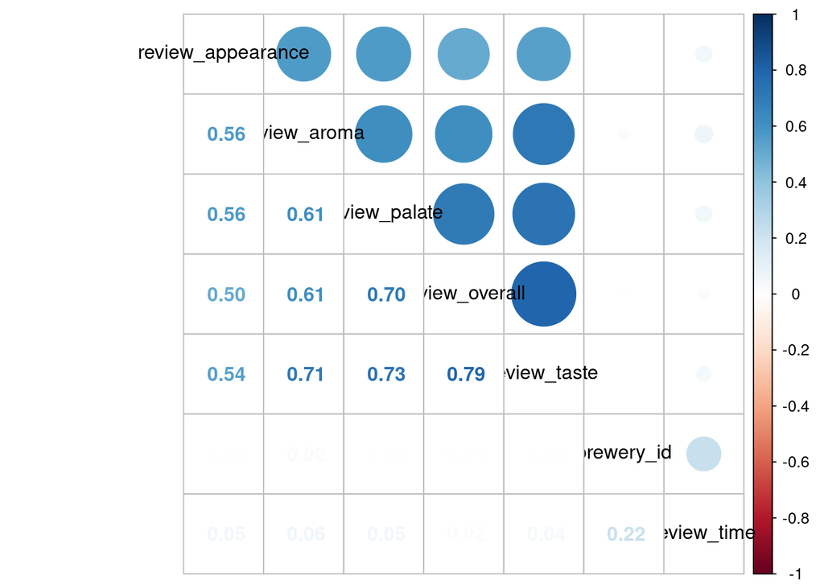

```r
# Calculamos el coeficiente de correlación para variables cuantitativas
correl <- round(cor(quandatos_m), 2)

# Se grafica la matriz de correlación
corrplot.mixed(correl, order="hclust", tl.col="black")
```

Otra forma de graficar la matriz:

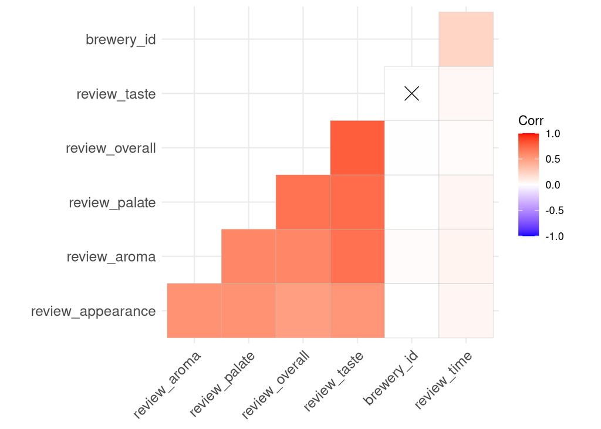

```r
# Graficamos la matriz de correlación utilizando ggcorrplot
ggcorrplot(correl, p.mat = cor_pmat(quandatos_m), hc.order=TRUE, type='lower')
```

Matriz con ggplot2:

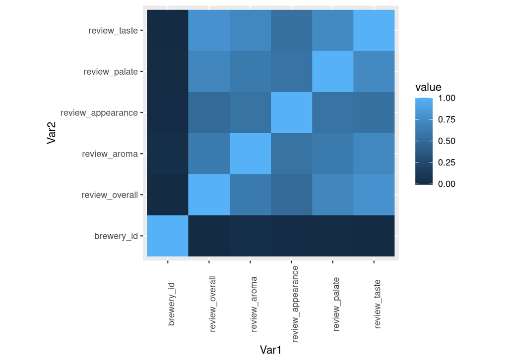

```r
library(ggplot2)
library(reshape2)
heat <- rev[, c("brewery_id", "review_overall", "review_aroma", "review_appearance", "review_palate", "review_taste")]

qplot(x=Var1, y=Var2, data=melt(cor(heat, use="p")), fill=value, geom="tile") +
   theme(axis.text.x = element_text(angle = 90)) +
   coord_fixed()
```

Por otro lado, también podemos utilizar un “heatmap” que nos permite ir un paso más allá y agrupar las variables que tienen más relación entre ellas. Esto nos servirá, eventualmente, para evitar escoger variables muy correlacionadas que nos puedan perjudicaren el momento de aplicar un modelo.

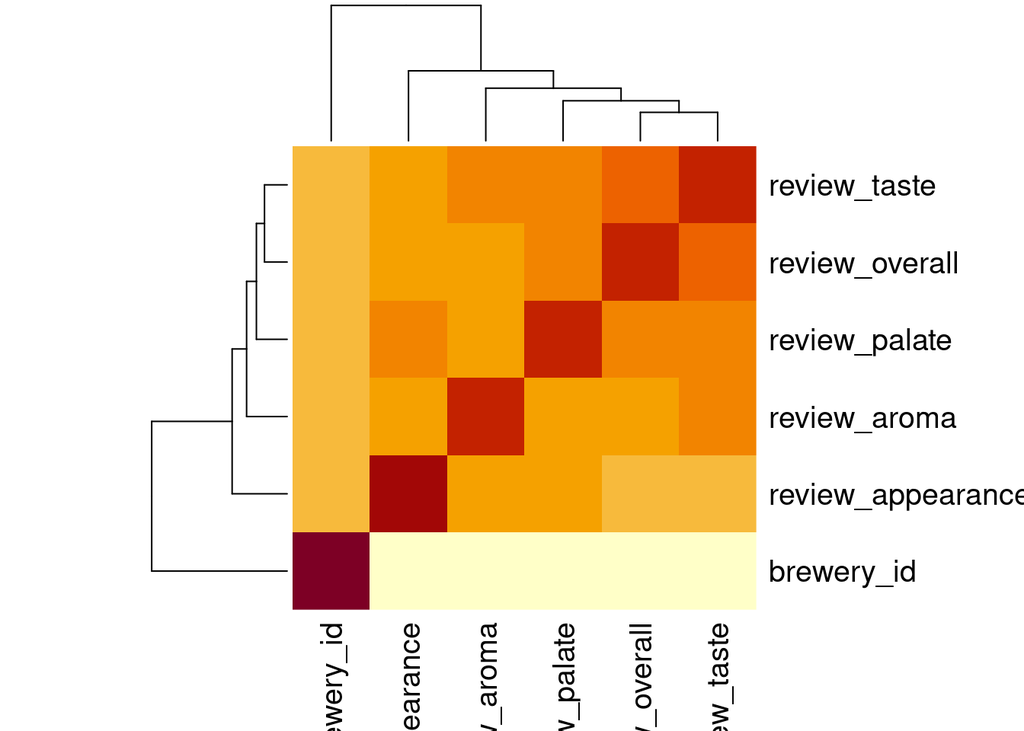

```r
revscaled <- as.matrix(scale(cor(heat, use="p")))

heatmap(revscaled, Colv=F, scale='none')
```

#### 3.2.5.5 Test de independencia de las variables categóricas:

Verificaremos la independencia de las variables categóricas con la prueba de independencia Chi-square de Pearson.

Se trata de una prueba que compara la distribución observada del conjunto de datos con la distribución esperada del conjunto de datos, puesto de otra manera, determina si el valor observado de una variable es dependiente de otra.

En primer lugar, tenemos que transformar nuestra variable “review_overall” a discreta para poder compararla con las demás categóricas. Para ello procedemos de la siguiente manera:

- beer_type y satisfaction:

```r
dat <- rev

dat$satisfaction <- ifelse(dat$review_overall < median(dat$review_overall),
  "bad", "good"
)
```

Generamos una tabla de contingencia con el número de casos para cada grupo:

```r
table(dat$satisfaction, dat$beer_type)
```

```
##
##           Ale Hybrid  Lager
##   bad  173625 300515  71790
##   good 301950 609300  39409
```

Generamos el test de independencia entre “satisfaction” y “beer_type”:

```r
library(summarytools)
library(dplyr)

# Test de independencia:
dat %$%
  ctable(satisfaction, beer_type,
    prop = "r", chisq = TRUE, headings = FALSE
  ) %>%
  print(
    method = "render",
    style = "rmarkdown",
    footnote = NA
  )
```

| **satisfaction** | beer_type Ale | beer_type Ale | beer_type Ale | beer_type Ale | beer_type Hybrid | beer_type Hybrid | beer_type Hybrid | beer_type Hybrid | beer_type Lager | beer_type Lager | beer_type Lager | beer_type Lager | Total | Total | Total | Total |
| --- | --- | --- | --- | --- | --- | --- | --- | --- | --- | --- | --- | --- | --- | --- | --- | --- |
| **bad** | 173625 | ( | 31.8% | ) | 300515 | ( | 55.0% | ) | 71790 | ( | 13.2% | ) | 545930 | ( | 100.0% | ) |
| **good** | 301950 | ( | 31.8% | ) | 609300 | ( | 64.1% | ) | 39409 | ( | 4.1% | ) | 950659 | ( | 100.0% | ) |
| **Total** | 475575 | ( | 31.8% | ) | 909815 | ( | 60.8% | ) | 111199 | ( | 7.4% | ) | 1496589 | ( | 100.0% | ) |

**Χ<sup>2</sup>** = 42511.3738 **df** = 2 **p** = .0000

```r
# Cálculo con la función chisq.test()
test <- chisq.test(table(dat$satisfaction, dat$beer_type))
test
```

```
##
##  Pearson's Chi-squared test
##
## data:  table(dat$satisfaction, dat$beer_type)
## X-squared = 42511, df = 2, p-value < 2.2e-16
```

Interpretación: Se rechaza la hipótesis nula de la prueba de independencia Chi-square, es decir, significa que existe una relación significativa entre tipo de cerveza y la calificación. Por lo tanto, conocer el valor de una variable ayuda a predecir el valor de la otra.

### 3.2.6 Reducción de la dimensionalidad:

Una vez tenemos nuestros datos preprocesados, cabe señalar que aún es posible aplicar operaciones con el fin de cumplir dos objetivos: la reducción del número de atributos y la reducción del número de muestras que hay que tratar, asegurando, asimismo, que se mantendrá o se mejorará la calidad del modelo resultante.

En nuestro caso, utilizaremos la técnica de los Componentes Principales. Esta técnica matemática lo que hace es buscar la dirección por donde existe mayor dispersión y, así, ir transformando un grupo de variables correlacionadas de acuerdo a cada muestra para determinar una serie de componentes principales “no correlacionados” tomando en cuenta la misma muestra.

Procedemos a realizar el análisis de compones principales (PCA) sobre las variables numéricas:

```r
reviews_pca <- prcomp(rev[, c(1,4:6,9,10,12,13)], center = TRUE, scale. = TRUE)
```

Importancia de los componentes:

```r
summary(reviews_pca)
```

```
## Importance of components:
##                           PC1    PC2    PC3     PC4     PC5     PC6     PC7
## Standard deviation     1.9176 1.1933 0.9400 0.77901 0.73993 0.62573 0.53257
## Proportion of Variance 0.4597 0.1780 0.1105 0.07586 0.06844 0.04894 0.03545
## Cumulative Proportion  0.4597 0.6377 0.7481 0.82396 0.89240 0.94134 0.97679
##                            PC8
## Standard deviation     0.43086
## Proportion of Variance 0.02321
## Cumulative Proportion  1.00000
```

Hemos obtenido 8 componentes. PC1 explica el 46% de la varianza total, lo que significa que casi la mitad de la información en el conjunto de datos (8 variables) pueden ser encapsuladas solo por ese Componente Principal. PC2 explica el 18% de la varianza. Entonces, al conocer la posición de una muestra en relación solo con PC1 y PC2, se puede tener una idea muy precisa de dónde se encuentra en relación con otras muestras, ya que solo PC1 y PC2 pueden explicar el 64% de la varianza.

Veamos su estructura:

```r
str(reviews_pca)
```

```
## List of 5
##  $ sdev    : num [1:8] 1.918 1.193 0.94 0.779 0.74 ...
##  $ rotation: num [1:8, 1:8] 0.0146 0.4374 0.4367 0.3845 0.4476 ...
##   ..- attr(*, "dimnames")=List of 2
##   .. ..$ : chr [1:8] "brewery_id" "review_overall" "review_aroma" "review_appearance" ...
##   .. ..$ : chr [1:8] "PC1" "PC2" "PC3" "PC4" ...
##  $ center  : Named num [1:8] 3067.92 3.83 3.75 3.85 3.75 ...
##   ..- attr(*, "names")= chr [1:8] "brewery_id" "review_overall" "review_aroma" "review_appearance" ...
##  $ scale   : Named num [1:8] 5540.945 0.718 0.695 0.614 0.679 ...
##   ..- attr(*, "names")= chr [1:8] "brewery_id" "review_overall" "review_aroma" "review_appearance" ...
##  $ x       : num [1:1496589, 1:8] 1.71 1.96 2.29 1.98 1.78 ...
##   ..- attr(*, "dimnames")=List of 2
##   .. ..$ : NULL
##   .. ..$ : chr [1:8] "PC1" "PC2" "PC3" "PC4" ...
##  - attr(*, "class")= chr "prcomp"
```

Observamos las desviaciones estándard:

```r
reviews_pca$sdev
```

```
## [1] 1.9176208 1.1932946 0.9399945 0.7790143 0.7399349 0.6257348 0.5325734
## [8] 0.4308639
```

Correlación y anticorrelación (“rotation”):

```r
reviews_pca$rotation
```

```
##                          PC1         PC2          PC3         PC4          PC5
## brewery_id        0.01458971 -0.63132670  0.492012131 -0.59696625  0.052057235
## review_overall    0.43737371  0.12756642  0.285319412  0.13305649  0.276954984
## review_aroma      0.43666340 -0.01390386 -0.036098248 -0.01092195  0.006492651
## review_appearance 0.38446718  0.01622363 -0.050092933 -0.12601356 -0.883918000
## review_palate     0.44761408  0.05056413  0.071177646  0.03556259  0.103551255
## review_taste      0.46958509  0.06603047  0.101159500  0.04630655  0.263406021
## beer_abv          0.21715548 -0.32126118 -0.810786583 -0.30312078  0.225937393
## beer_beerid       0.04445692 -0.68889142 -0.005488682  0.71738229 -0.089886022
##                            PC6          PC7          PC8
## brewery_id        -0.006512472 -0.004075892 -0.000339189
## review_overall    -0.176047913  0.533202326  0.548924583
## review_aroma       0.822043459 -0.289949607  0.218725873
## review_appearance -0.126431241  0.187884555 -0.030603408
## review_palate     -0.506795358 -0.719878551  0.070458683
## review_taste       0.049400824  0.233955537 -0.797617649
## beer_abv          -0.132906351  0.152380744  0.091901946
## beer_beerid       -0.016683491  0.011272694 -0.017314863
```

Generamos un plot para ver los PCA y sus varianzas:

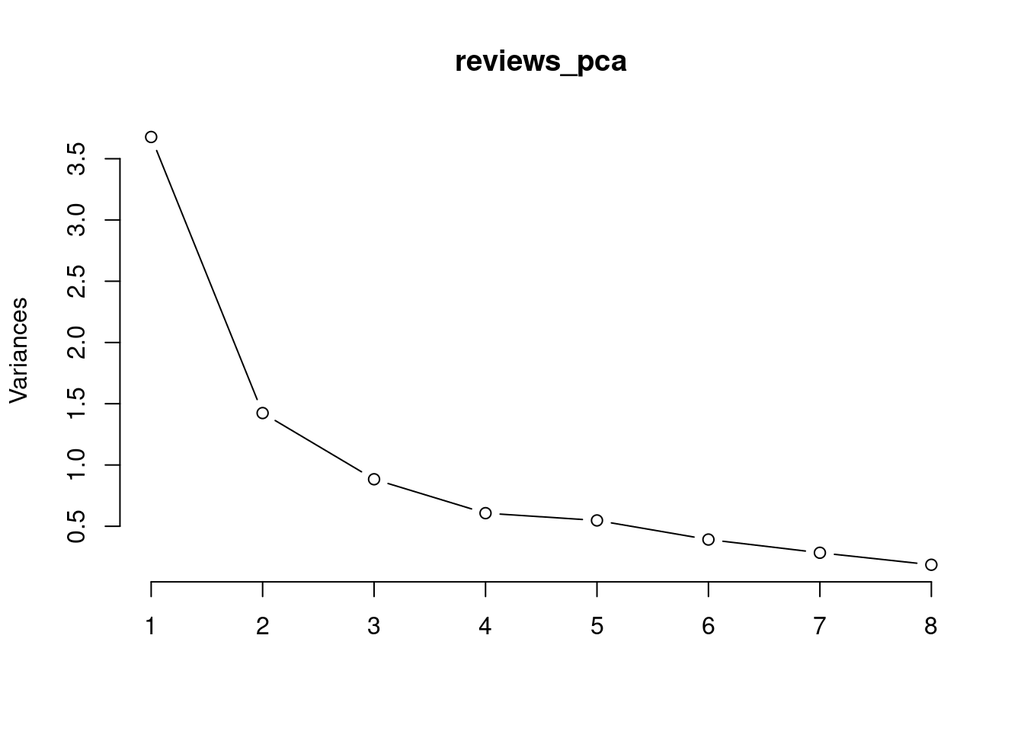

```r
plot(reviews_pca, type = "lines")
```

Visualización del Porcentaje total de la varianza explicada por cada componente:

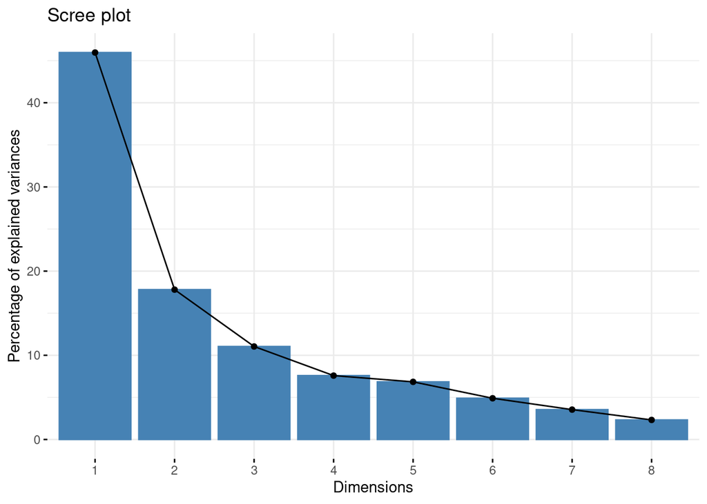

```r
library("factoextra")
fviz_eig(reviews_pca)
```

El primer componente explica 46% de la variación en el conjunto de datos. En conclusión, el primer componente claramente acumula el mayor porcentaje y las desviaciones estándar no son muy cercanas entre componentes (1.92-0.43), lo que nos puede llevar a pensar en replantear el estudio y redimensionar el espectro de variables. Siempre estamos a tiempo de elegir y tomar distintos caminos.

### 3.2.7 Conclusiones:

En lo que respecta al conjunto de datos hace falta la variable IBU (International Bitterness Units scale), muy determinante para establecer el sabor y textura de la cerveza.

Por otro lado, el conjunto de datos carece de variables categóricas tipo País o Región para hacer una análisis más profundo.

En lo que se refiere a la variable dependiente se podría establecer un modelo con el dataset para predecir si las opiniones de expertos influirán en las decisiones de compra de los consumidores de cerveza. Es decir, hablamos de modelos de clasificación. Asimismo, el dataset se puede orientar hacia el estudio de “sistemas de recomendación”, ya que nuestros hábitos de compra, dada nuestra naturaleza social, está muy fuertemente influenciada por lo que comentan o “califican” otras personas.

Asimismo, podemos rescatar que el estilo de la cerveza tiene una significancia estadística que impacta en las calificaciones (“reviews_overall”) de los consumidores.

De otro lado, cervezas con un mayor grado de alcohol (“strong”) tienden a generar mayor número de “reviews”. Es lógico pensar que la sociedad en general y, en especial el consumidor de cerveza, tiende a tratar de encontrar su “happy hour” después de largas jornadas de trabajo.

Por otra parte, las cervezas tipo “ALE” tienen una distribución simétrica que nos lleva a pensar que no hay mucha diferencia de opinión entre grupos de amantes de la cerveza y su calificación suele tener una mediana con puntuación de 4.

Finalmente, destacar que las distribuciones de las calificaciones muestran un sesgo a la izquierda, esto debido a la asimetría de las variables de tipo calificación. Es decir, hay una tendencia “natural” a dar una calificación media alta. ¡Es la naturaleza magnánima del ser humano!

### 3.2.8 Bibliografía y documentación:

- Insider magazine [en línea] [consulta: 25 de octubre de 2021]. Disponible en: https://www.insider.com/types-of-beer.
- Blog difference between [en línea] [consulta: 23 de octubre de 2021]. Disponible en: http://www.differencebetween.info/difference-between-lager-beer-and-strong-beer.

# 4 Criterios de evaluación

Ejercicio 1

Concepto y peso en la nota final

El objetivo del proyecto está correctamente definido con suficiente concreción y se puede resolver con técnicas de minería de datos. 15%

Las fases del ciclo de vida están bien expresadas. Los ejemplos son clarificadores. Se justifica y argumenta de las decisiones que se han tomado. 20%

Ejercicio 2

Se carga la base de datos, se visualiza su estructura y se explican los hechos básicos de los datos. 5%

Se estudia si existen atributos vacíos o en diferentes escalas que haya que normalizar. Si es el caso se adoptan medidas para tratar estos atributos. Se construye un nueva variable útil a partir de las existentes. Se discretiza algún atributo. 20%

Se analizan los datos de forma visual y extraen conclusiones tangibles. Hay que elaborar un discurso coherente y con conclusiones claras. 30%

Se trata en profundidad alguno otro aspecto respecto a los datos presentado en los módulos “Preprocesado de los datos y gestión de características” 10%